# Exploratory data analysis for Rossmann Store Sales

Juan L. Kehoe

10/12/2015

# Basic information

Competition link: https://www.kaggle.com/c/rossmann-store-sales  
Data download link: https://www.kaggle.com/thie1e/exploratory-analysis-rossmann/data

## Purpose of the project

Predict 6 weeks of daily sales for 1,115 stores located across Germany.

## Data provided:

You are provided with historical sales data for 1,115 Rossmann stores. The task is to forecast the “Sales” column for the test set. Note that some stores in the dataset were temporarily closed for refurbishment.

### Files

- train.csv - historical data including Sales
- test.csv - historical data excluding Sales
- store.csv - supplemental information about the stores

### Data fields

Most of the fields are self-explanatory. The following are descriptions for those that aren’t.

- Id - an Id that represents a (Store, Date) duple within the test set
- Store - a unique Id for each store
- Sales - the turnover for any given day (this is what you are predicting)
- Customers - the number of customers on a given day
- Open - an indicator for whether the store was open: 0 = closed, 1 = open
- StateHoliday - indicates a state holiday. Normally all stores, with few exceptions, are closed on state holidays. Note that all schools are closed on public holidays and weekends. a = public holiday, b = Easter holiday, c = Christmas, 0 = None
- SchoolHoliday - indicates if the (Store, Date) was affected by the closure of public schools
- StoreType - differentiates between 4 different store models: a, b, c, d
- Assortment - describes an assortment level: a = basic, b = extra, c = extended
- CompetitionDistance - distance in meters to the nearest competitor store
- CompetitionOpenSince[Month/Year] - gives the approximate year and month of the time the nearest competitor was opened
- Promo - indicates whether a store is running a promo on that day
- Promo2 - Promo2 is a continuing and consecutive promotion for some stores: 0 = store is not participating, 1 = store is participating
- Promo2Since[Year/Week] - describes the year and calendar week when the store started participating in Promo2
- PromoInterval - describes the consecutive intervals Promo2 is started, naming the months the promotion is started anew. E.g. “Feb,May,Aug,Nov” means each round starts in February, May, August, November of any given year for that store

# Exploratory data analysis

## read data and check details

```r
# read data
train <- read.csv("train.csv")
test <- read.csv("test.csv")
store <- read.csv("store.csv")
# check data dimensions
dim(train)
```

```
## [1] 1017209       9
```

```r
dim(test)
```

```
## [1] 41088     8
```

```r
dim(store)
```

```
## [1] 1115   10
```

```r
# check variable details
str(train)
```

```
## 'data.frame':    1017209 obs. of  9 variables:
##  $ Store        : int  1 2 3 4 5 6 7 8 9 10 ...
##  $ DayOfWeek    : int  5 5 5 5 5 5 5 5 5 5 ...
##  $ Date         : Factor w/ 942 levels "2013-01-01","2013-01-02",..: 942 942 942 942 942 942 942 942 942 942 ...
##  $ Sales        : int  5263 6064 8314 13995 4822 5651 15344 8492 8565 7185 ...
##  $ Customers    : int  555 625 821 1498 559 589 1414 833 687 681 ...
##  $ Open         : int  1 1 1 1 1 1 1 1 1 1 ...
##  $ Promo        : int  1 1 1 1 1 1 1 1 1 1 ...
##  $ StateHoliday : Factor w/ 4 levels "0","a","b","c": 1 1 1 1 1 1 1 1 1 1 ...
##  $ SchoolHoliday: int  1 1 1 1 1 1 1 1 1 1 ...
```

```r
str(test)
```

```
## 'data.frame':    41088 obs. of  8 variables:
##  $ Id           : int  1 2 3 4 5 6 7 8 9 10 ...
##  $ Store        : int  1 3 7 8 9 10 11 12 13 14 ...
##  $ DayOfWeek    : int  4 4 4 4 4 4 4 4 4 4 ...
##  $ Date         : Factor w/ 48 levels "2015-08-01","2015-08-02",..: 48 48 48 48 48 48 48 48 48 48 ...
##  $ Open         : int  1 1 1 1 1 1 1 1 1 1 ...
##  $ Promo        : int  1 1 1 1 1 1 1 1 1 1 ...
##  $ StateHoliday : Factor w/ 2 levels "0","a": 1 1 1 1 1 1 1 1 1 1 ...
##  $ SchoolHoliday: int  0 0 0 0 0 0 0 0 0 0 ...
```

```r
str(store)
```

```
## 'data.frame':    1115 obs. of  10 variables:
##  $ Store                    : int  1 2 3 4 5 6 7 8 9 10 ...
##  $ StoreType                : Factor w/ 4 levels "a","b","c","d": 3 1 1 3 1 1 1 1 1 1 ...
##  $ Assortment               : Factor w/ 3 levels "a","b","c": 1 1 1 3 1 1 3 1 3 1 ...
##  $ CompetitionDistance      : int  1270 570 14130 620 29910 310 24000 7520 2030 3160 ...
##  $ CompetitionOpenSinceMonth: int  9 11 12 9 4 12 4 10 8 9 ...
##  $ CompetitionOpenSinceYear : int  2008 2007 2006 2009 2015 2013 2013 2014 2000 2009 ...
##  $ Promo2                   : int  0 1 1 0 0 0 0 0 0 0 ...
##  $ Promo2SinceWeek          : int  NA 13 14 NA NA NA NA NA NA NA ...
##  $ Promo2SinceYear          : int  NA 2010 2011 NA NA NA NA NA NA NA ...
##  $ PromoInterval            : Factor w/ 4 levels "","Feb,May,Aug,Nov",..: 1 3 3 1 1 1 1 1 1 1 ...
```

```r
# check the first 6 rows of the data
head(train)
```

```
##   Store DayOfWeek       Date Sales Customers Open Promo StateHoliday
## 1     1         5 2015-07-31  5263       555    1     1            0
## 2     2         5 2015-07-31  6064       625    1     1            0
## 3     3         5 2015-07-31  8314       821    1     1            0
## 4     4         5 2015-07-31 13995      1498    1     1            0
## 5     5         5 2015-07-31  4822       559    1     1            0
## 6     6         5 2015-07-31  5651       589    1     1            0
##   SchoolHoliday
## 1             1
## 2             1
## 3             1
## 4             1
## 5             1
## 6             1
```

```r
head(test)
```

```
##   Id Store DayOfWeek       Date Open Promo StateHoliday SchoolHoliday
## 1  1     1         4 2015-09-17    1     1            0             0
## 2  2     3         4 2015-09-17    1     1            0             0
## 3  3     7         4 2015-09-17    1     1            0             0
## 4  4     8         4 2015-09-17    1     1            0             0
## 5  5     9         4 2015-09-17    1     1            0             0
## 6  6    10         4 2015-09-17    1     1            0             0
```

```r
head(store)
```

```
##   Store StoreType Assortment CompetitionDistance CompetitionOpenSinceMonth
## 1     1         c          a                1270                         9
## 2     2         a          a                 570                        11
## 3     3         a          a               14130                        12
## 4     4         c          c                 620                         9
## 5     5         a          a               29910                         4
## 6     6         a          a                 310                        12
##   CompetitionOpenSinceYear Promo2 Promo2SinceWeek Promo2SinceYear
## 1                     2008      0              NA              NA
## 2                     2007      1              13            2010
## 3                     2006      1              14            2011
## 4                     2009      0              NA              NA
## 5                     2015      0              NA              NA
## 6                     2013      0              NA              NA
##     PromoInterval
## 1
## 2 Jan,Apr,Jul,Oct
## 3 Jan,Apr,Jul,Oct
## 4
## 5
## 6
```

```r
# check the last 6 rows of the data
tail(train)
```

```
##         Store DayOfWeek       Date Sales Customers Open Promo StateHoliday
## 1017204  1110         2 2013-01-01     0         0    0     0            a
## 1017205  1111         2 2013-01-01     0         0    0     0            a
## 1017206  1112         2 2013-01-01     0         0    0     0            a
## 1017207  1113         2 2013-01-01     0         0    0     0            a
## 1017208  1114         2 2013-01-01     0         0    0     0            a
## 1017209  1115         2 2013-01-01     0         0    0     0            a
##         SchoolHoliday
## 1017204             1
## 1017205             1
## 1017206             1
## 1017207             1
## 1017208             1
## 1017209             1
```

```r
tail(test)
```

```
##          Id Store DayOfWeek       Date Open Promo StateHoliday
## 41083 41083  1109         6 2015-08-01    1     0            0
## 41084 41084  1111         6 2015-08-01    1     0            0
## 41085 41085  1112         6 2015-08-01    1     0            0
## 41086 41086  1113         6 2015-08-01    1     0            0
## 41087 41087  1114         6 2015-08-01    1     0            0
## 41088 41088  1115         6 2015-08-01    1     0            0
##       SchoolHoliday
## 41083             0
## 41084             0
## 41085             0
## 41086             0
## 41087             0
## 41088             1
```

```r
tail(store)
```

```
##      Store StoreType Assortment CompetitionDistance
## 1110  1110         c          c                 900
## 1111  1111         a          a                1900
## 1112  1112         c          c                1880
## 1113  1113         a          c                9260
## 1114  1114         a          c                 870
## 1115  1115         d          c                5350
##      CompetitionOpenSinceMonth CompetitionOpenSinceYear Promo2
## 1110                         9                     2010      0
## 1111                         6                     2014      1
## 1112                         4                     2006      0
## 1113                        NA                       NA      0
## 1114                        NA                       NA      0
## 1115                        NA                       NA      1
##      Promo2SinceWeek Promo2SinceYear    PromoInterval
## 1110              NA              NA
## 1111              31            2013  Jan,Apr,Jul,Oct
## 1112              NA              NA
## 1113              NA              NA
## 1114              NA              NA
## 1115              22            2012 Mar,Jun,Sept,Dec
```

## merge data and transform data type

```r
# merge data
train <- merge(train,store,by="Store")
test <- merge(test,store,by="Store")
# transform the data type
# train
train$Store <- as.factor(train$Store)
train$DayOfWeek <- as.factor(train$DayOfWeek)
train$Open <- as.factor(train$Open)
train$Promo <- as.factor(train$Promo)
train$StateHoliday <- as.factor(train$StateHoliday)
train$SchoolHoliday <- as.factor(train$SchoolHoliday)
train$Assortment <- as.factor(train$Assortment)
train$StoreType <- as.factor(train$StoreType)
train$Promo2 <- as.factor(train$Promo2)
train$PromoInterval <- as.factor(train$PromoInterval)
train$Date <- as.Date(train$Date)

# test
test$Store <- as.factor(test$Store)
test$DayOfWeek <- as.factor(test$DayOfWeek)
test$Open <- as.factor(test$Open)
test$Promo <- as.factor(test$Promo)
test$StateHoliday <- as.factor(test$StateHoliday)
test$SchoolHoliday <- as.factor(test$SchoolHoliday)
test$Assortment <- as.factor(test$Assortment)
test$StoreType <- as.factor(test$StoreType)
test$Promo2 <- as.factor(test$Promo2)
test$PromoInterval <- as.factor(test$PromoInterval)
test$Date <- as.Date(test$Date)

# extract the month information
train$Month <- as.factor(format(train$Date, "%m"))
test$Month <- as.factor(format(test$Date, "%m"))
# extract year information
train$Year <- as.factor(format(train$Date, "%Y"))
test$Year <- as.factor(format(test$Date, "%Y"))
# extract day information
train$Day <- as.factor(format(train$Date, "%d"))
test$Day <- as.factor(format(test$Date, "%d"))
```

## explore data

### data summaries

```r
# summary of data
summary(train)
```

```
##      Store         DayOfWeek       Date                Sales
##  1      :    942   1:144730   Min.   :2013-01-01   Min.   :    0
##  2      :    942   2:145664   1st Qu.:2013-08-17   1st Qu.: 3727
##  3      :    942   3:145665   Median :2014-04-02   Median : 5744
##  4      :    942   4:145845   Mean   :2014-04-11   Mean   : 5774
##  5      :    942   5:145845   3rd Qu.:2014-12-12   3rd Qu.: 7856
##  6      :    942   6:144730   Max.   :2015-07-31   Max.   :41551
##  (Other):1011557   7:144730
##    Customers      Open       Promo      StateHoliday SchoolHoliday
##  Min.   :   0.0   0:172817   0:629129   0:986159     0:835488
##  1st Qu.: 405.0   1:844392   1:388080   a: 20260     1:181721
##  Median : 609.0                         b:  6690
##  Mean   : 633.1                         c:  4100
##  3rd Qu.: 837.0
##  Max.   :7388.0
##
##  StoreType  Assortment CompetitionDistance CompetitionOpenSinceMonth
##  a:551627   a:537445   Min.   :   20       Min.   : 1.0
##  b: 15830   b:  8294   1st Qu.:  710       1st Qu.: 4.0
##  c:136840   c:471470   Median : 2330       Median : 8.0
##  d:312912              Mean   : 5430       Mean   : 7.2
##                        3rd Qu.: 6890       3rd Qu.:10.0
##                        Max.   :75860       Max.   :12.0
##                        NA's   :2642        NA's   :323348
##  CompetitionOpenSinceYear Promo2     Promo2SinceWeek  Promo2SinceYear
##  Min.   :1900             0:508031   Min.   : 1.0     Min.   :2009
##  1st Qu.:2006             1:509178   1st Qu.:13.0     1st Qu.:2011
##  Median :2010                        Median :22.0     Median :2012
##  Mean   :2009                        Mean   :23.3     Mean   :2012
##  3rd Qu.:2013                        3rd Qu.:37.0     3rd Qu.:2013
##  Max.   :2015                        Max.   :50.0     Max.   :2015
##  NA's   :323348                      NA's   :508031   NA's   :508031
##           PromoInterval        Month          Year             Day
##                  :508031   03     :103695   2013:406974   02     : 33485
##  Feb,May,Aug,Nov :118596   05     :103695   2014:373855   03     : 33485
##  Jan,Apr,Jul,Oct :293122   01     :103694   2015:236380   04     : 33485
##  Mar,Jun,Sept,Dec: 97460   04     :100350                 05     : 33485
##                            06     :100350                 06     : 33485
##                            07     : 98115                 07     : 33485
##                            (Other):407310                 (Other):816299
```

```r
summary(test)
```

```
##      Store             Id        DayOfWeek      Date
##  1      :   48   Min.   :    1   1:5992    Min.   :2015-08-01
##  3      :   48   1st Qu.:10273   2:5992    1st Qu.:2015-08-12
##  7      :   48   Median :20544   3:5992    Median :2015-08-24
##  8      :   48   Mean   :20544   4:5992    Mean   :2015-08-24
##  9      :   48   3rd Qu.:30816   5:5136    3rd Qu.:2015-09-05
##  10     :   48   Max.   :41088   6:5992    Max.   :2015-09-17
##  (Other):40800                   7:5992
##    Open       Promo     StateHoliday SchoolHoliday StoreType Assortment
##  0   : 5984   0:24824   0:40908      0:22866       a:22128   a:20304
##  1   :35093   1:16264   a:  180      1:18222       b:  576   b:  432
##  NA's:   11                                        c: 4272   c:20352
##                                                    d:14112
##
##
##
##  CompetitionDistance CompetitionOpenSinceMonth CompetitionOpenSinceYear
##  Min.   :   20       Min.   : 1.000            Min.   :1900
##  1st Qu.:  720       1st Qu.: 4.000            1st Qu.:2006
##  Median : 2425       Median : 7.000            Median :2010
##  Mean   : 5089       Mean   : 7.035            Mean   :2009
##  3rd Qu.: 6480       3rd Qu.: 9.000            3rd Qu.:2012
##  Max.   :75860       Max.   :12.000            Max.   :2015
##  NA's   :96          NA's   :15216             NA's   :15216
##  Promo2    Promo2SinceWeek Promo2SinceYear          PromoInterval
##  0:17232   Min.   : 1.00   Min.   :2009                    :17232
##  1:23856   1st Qu.:13.00   1st Qu.:2011    Feb,May,Aug,Nov : 5712
##            Median :22.00   Median :2012    Jan,Apr,Jul,Oct :13776
##            Mean   :24.43   Mean   :2012    Mar,Jun,Sept,Dec: 4368
##            3rd Qu.:37.00   3rd Qu.:2013
##            Max.   :49.00   Max.   :2015
##            NA's   :17232   NA's   :17232
##  Month        Year            Day
##  08:26536   2015:41088   01     : 1712
##  09:14552                02     : 1712
##                          03     : 1712
##                          04     : 1712
##                          05     : 1712
##                          06     : 1712
##                          (Other):30816
```

### Visulize data in train

```r
# load package
library(dplyr)
```

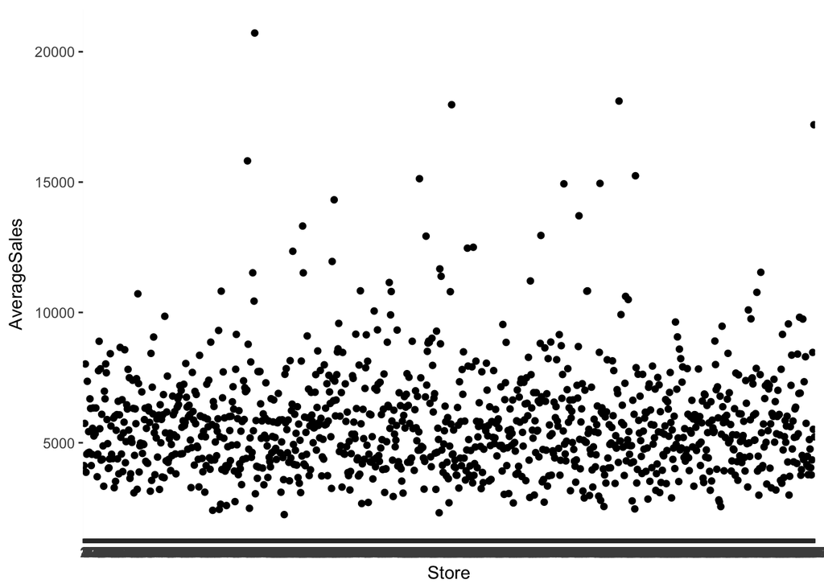

```r
library(ggplot2)
# average sales in all stores
train %>%
  group_by(Store) %>% summarize(AverageSales=mean(Sales)) %>%
  ggplot(aes(x=Store, y=AverageSales)) + geom_point()
```

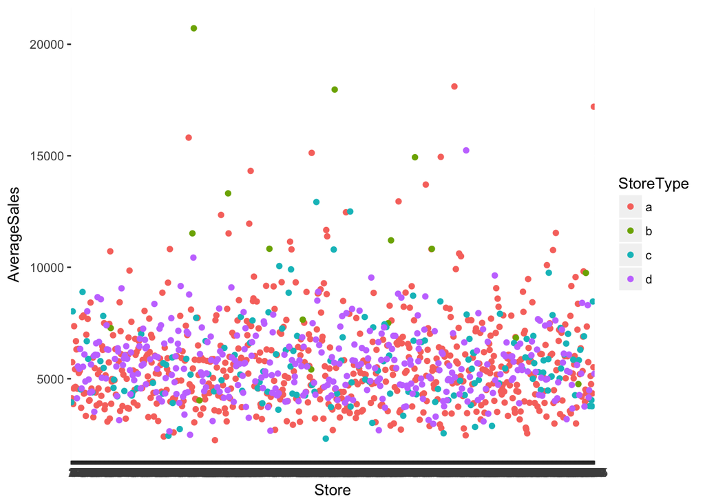

```r
# average sales for different store types
train %>%
  group_by(StoreType, Store) %>% summarize(AverageSales=mean(Sales)) %>%
  ggplot(aes(x=Store, y=AverageSales)) + geom_point(aes(colour=StoreType))
```

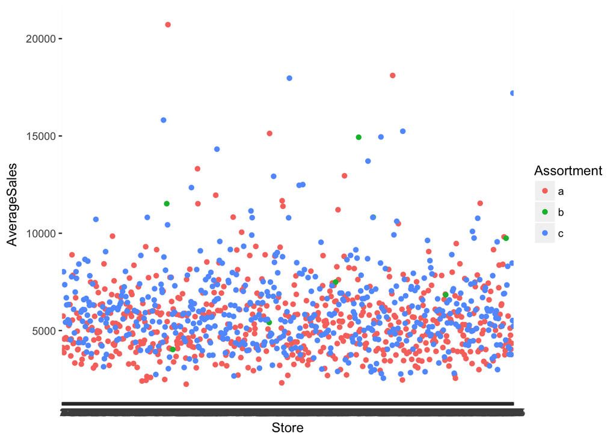

```r
# average sales for different assortment types
train %>%
  group_by(Assortment, Store) %>% summarize(AverageSales=mean(Sales)) %>%
  ggplot(aes(x=Store, y=AverageSales)) + geom_point(aes(colour=Assortment))
```

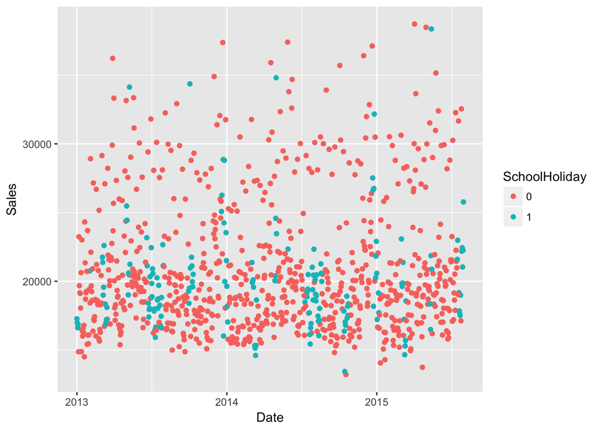

```r
# take store number 262 as an example to view the sales
# different school holidays
train %>% subset(Store=="262") %>% ggplot(aes(y=Sales, x=Date)) + geom_point(aes(colour=SchoolHoliday))
```

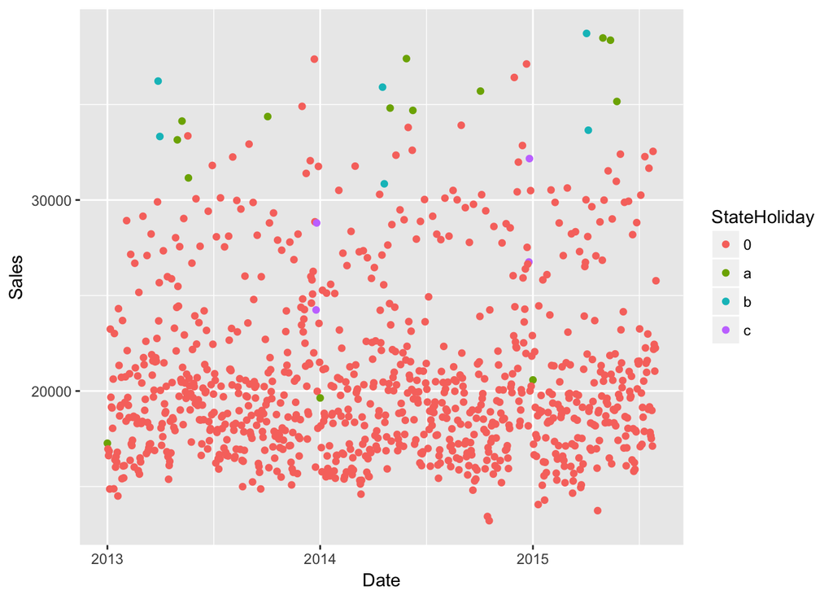

```r
# different state holidays
train %>% subset(Store=="262") %>% ggplot(aes(y=Sales, x=Date)) + geom_point(aes(colour=StateHoliday))
```

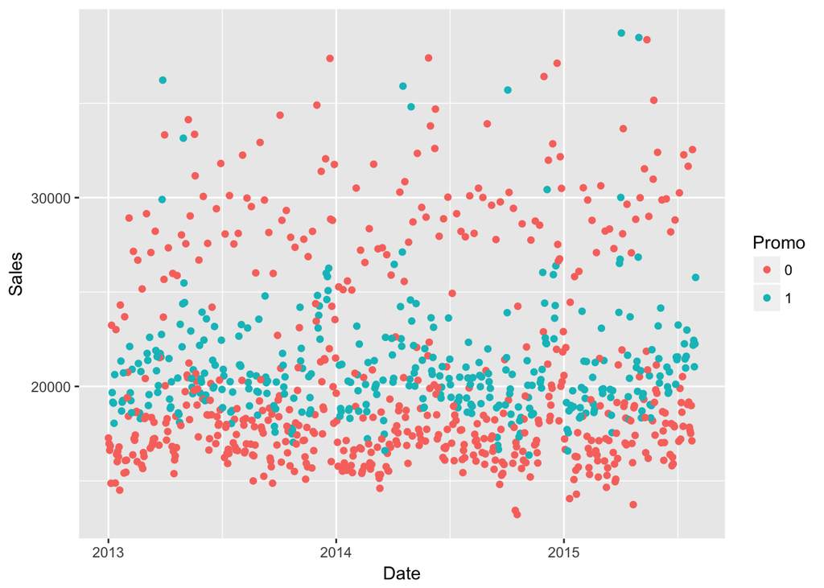

```r
# different promotion status
train %>% subset(Store=="262") %>% ggplot(aes(y=Sales, x=Date)) + geom_point(aes(colour=Promo))
```

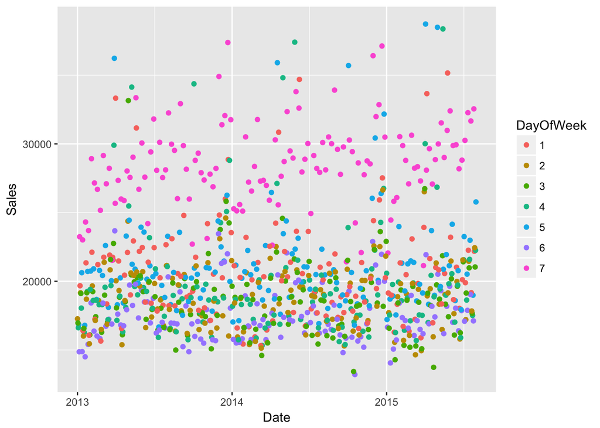

```r
# different day of week
train %>% subset(Store=="262") %>% ggplot(aes(y=Sales, x=Date)) + geom_point(aes(colour=DayOfWeek))
```

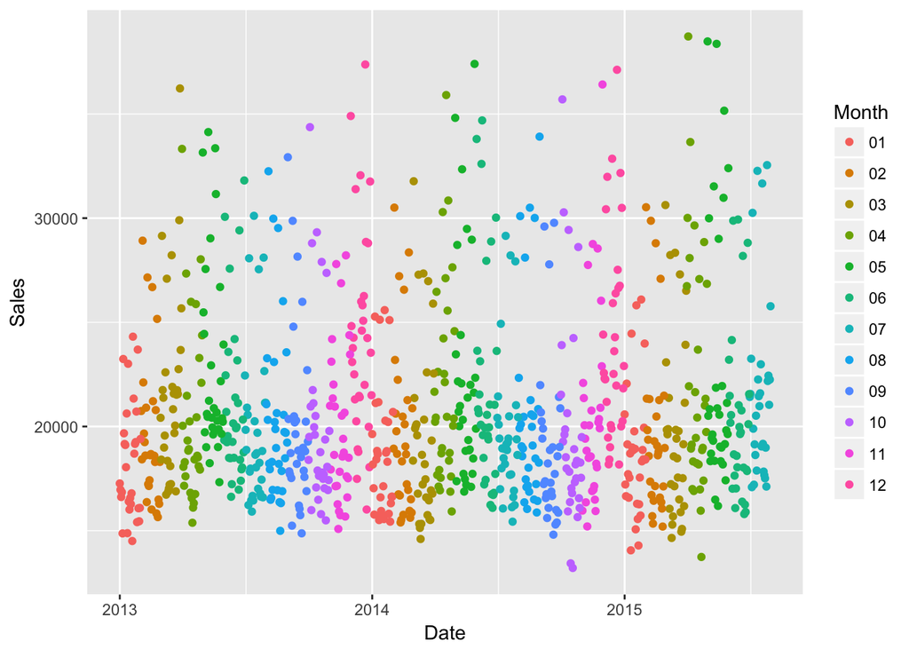

```r
# different month
train %>% subset(Store=="262") %>% ggplot(aes(y=Sales, x=Date)) + geom_point(aes(colour=Month))
```